# Simulating from mixed-effects general hazard models (MEGH)

[F. Javier Rubio](https://sites.google.com/site/fjavierrubio67/) and Reza Drikvandi

27 September, 2021

# MEGH Structure

The MEGH model was proposed by Rubio and Drikvandi (2021) in terms of the hazard function: Let $o_{ij} \in {\mathbb R}_+$, $j=1,\dots,n_i$, $i=1,\dots,r$, be a sample of times-to-event of interest, and ${\bf x}_{ij}\in{\mathbb R}^p$ be a vector of covariates associated to the $ij$th individual. Let $c_{ij} \in {\mathbb R}_+$ be the right-censoring indicators, and $t_{ij} = \min\{o_{ij},c_{ij}\}$ be the observed survival times. Let $d_{ij} = I(o_{ij} < c_{ij})$ be the vital status indicators (1 - dead, 0 - alive), and $n = \sum_{i = 1}^r n_i$ be the total sample size. We propose the mixed-effects general hazards (MEGH) model, which is defined through the individual hazard function:
$$h(t_{ij}\mid {\bf x}_{ij}, {\bf u}_i, \tilde{{\bf u}}_i) = h_0\left(t_{ij} \exp\left\{\tilde{{\bf x}}_{ij}^{\top}\mathbf{\alpha} + \tilde{{\bf z}}_{ij}^{\top}\tilde{{\bf u}}_i \right\}\right)\exp\left\{{\bf x}_{ij}^{\top}\mathbf{\beta} + {\bf z}_{ij}^{\top}{\bf u}_i \right\},$$
where $h_0(\cdot)$ is a baseline hazard, $\mathbf{\beta}=(\beta_1,\ldots,\beta_p)^\top \in \mathbb{R}^p$, $\mathbf{\alpha}=(\alpha_1,\ldots,\alpha_q)^\top \in \mathbb{R}^{\tilde{p}}$, ${{\bf x}}_{ij}\in \mathbb{R}^p$ is a vector of covariates affecting the hazard scale, $\tilde{{\bf x}}_{ij} \in \mathbb{R}^{\tilde{p}}$ is a vector of covariates affecting the time scale (typically, $\tilde{{\bf x}}_{ij} \subset {\bf x}_{ij}$), and $({\bf u}_i,\tilde{{\bf u}}_i) \stackrel{iid}{\sim} G_{q+\tilde{q}}$, where $G_{q+\tilde{q}}$ is a continuous distribution with support on ${\mathbb R}^{q + \tilde{q}}$.

Suppose that $q=\tilde{q} = 1$ and that $G_{q+\tilde{q}}$ is a bivariate normal distribution with zero mean and covariance matrix $\Sigma$. The following R code shows how to simulate from the MEGH model under these assumptions for specific values of the parameters and a baseline hazard given by the [Power Generalised Weibull](https://rpubs.com/FJRubio/PGW) distribution. In order to avoid simulating design matrices, we will use the real data set `LeukSurv` from the R package `spBayesSurv`.

```r
##############################################################################################
# MEGH
##############################################################################################

# Required packages
library(mvtnorm)
#library(devtools)
#install_github("FJRubio67/MEGH")
library(MEGH)
library(spBayesSurv)

#********************************************************
# Design matrices and ID indicators based on real data
#********************************************************

data(LeukSurv)
#View(LeukSurv)
#dim(LeukSurv)

X <- as.matrix(cbind(scale(LeukSurv$age), LeukSurv$sex, scale(LeukSurv$wbc), scale(LeukSurv$tpi) ))
colnames(X) <- cbind("std age", "sex", "wbc", "tpi")
Xt <- as.matrix(cbind(scale(LeukSurv$age)))
n.ind <- dim(X)[1]  # number of individuals
n.clust <- length(unique(LeukSurv$district)) # number of clusters
q <- dim(Xt)[2]
p <- dim(X)[2]
r <- n.clust
ID <- as.vector(LeukSurv$district)


#True values of the parameters
Sigma <- cbind(c(1,0.5),c(0.5,1))
alpha <- 0.96
beta <- c(1.00,0.08,0.22,0.10)
theta <- c(0.2,1.50,3.0)
true_parameters <- c(sigma,theta,alpha,beta)
npar <- length(true_parameters)
cens <- 4 # censoring times


#********************************************************
# Simulation
#********************************************************
#*
simulated_survival <- simMEGH(seed=1234, des=X, des_t=Xt, ID=ID,
                              alpha=alpha, beta=beta, theta=theta, Sigma=Sigma,
                              cens=rep(cens,n.ind), restr="GENERAL", distr="PGW")

summary(simulated_survival)
```

```
##        Length Class  Mode
## times  1043   -none- numeric
## status 1043   -none- numeric
## ID     1043   -none- numeric
```

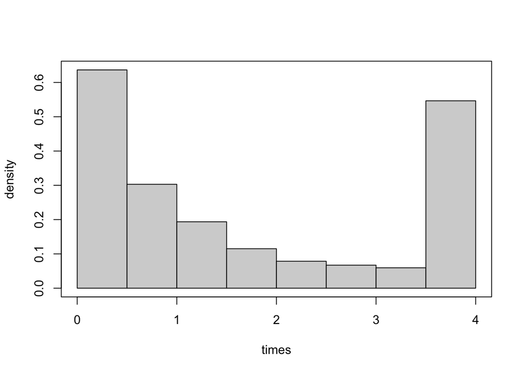

```r
# Histogram of survival times
hist(simulated_survival$times, xlab = "times", ylab ="density", probability = TRUE, main = "")
box()
```

```r
# Proportion of observed survival times
mean(simulated_survival$status)
```

```
## [1] 0.7526366
```

# MEGH-I and MEGH-II sub-structures

Rubio and Drikvandi (2021) proposed two sub-structures of the MEGH structure.

## MEGH-I Structure

The first proposed mixed effects hazard structure is:
$$h_1(t_{ij}\mid {\bf x}_{ij}, {\bf u}_i) = h_0\left(t_{ij} \exp\left\{\tilde{{\bf x}}_{ij}^{\top}\mathbf{\alpha}\right\}\right)\exp\left\{{\bf x}_{ij}^{\top}\mathbf{\beta} + {\bf z}_{ij}^{\top}{\bf u}_i \right\},$$

This mixed hazard structure contains the mixed effects proportional hazards (MEPH, $\mathbf{\alpha} = 0$) model Therneau and Grambsch (2000), while allowing for the inclusion of time-dependent effects through the parameter $\mathbf{\alpha}$.

The following R code shows how to simulate from the MEGH-I model under these assumptions for specific values of the parameters and a baseline hazard given by the [Power Generalised Weibull](https://rpubs.com/FJRubio/PGW) distribution. In order to avoid simulating design matrices, we will use the real data set `LeukSurv` from the R package `spBayesSurv`.

```r
##############################################################################################
# MEGH-I
##############################################################################################

# Required packages
library(mvtnorm)
library(MEGH)
library(spBayesSurv)

#********************************************************
# Design matrices and ID indicators based on real data
#********************************************************

data(LeukSurv)
#View(LeukSurv)
#dim(LeukSurv)

X <- as.matrix(cbind(scale(LeukSurv$age), LeukSurv$sex, scale(LeukSurv$wbc), scale(LeukSurv$tpi) ))
colnames(X) <- cbind("std age", "sex", "wbc", "tpi")
Xt <- as.matrix(cbind(scale(LeukSurv$age)))
n.ind <- dim(X)[1]  # number of individuals
n.clust <- length(unique(LeukSurv$district)) # number of clusters
q <- dim(Xt)[2]
p <- dim(X)[2]
r <- n.clust
ID <- as.vector(LeukSurv$district)


#True values of the parameters
Sigma <- 1
alpha <- 0.96
beta <- c(1.00,0.08,0.22,0.10)
theta <- c(0.2,1.50,3.0)
true_parameters <- c(sigma,theta,alpha,beta)
npar <- length(true_parameters)
cens <- 4 # censoring times


#********************************************************
# Simulation
#********************************************************
#*
simulated_survival <- simMEGH(seed=1234, des=X, des_t=Xt, ID=ID,
                              alpha=alpha, beta=beta, theta=theta, Sigma=Sigma,
                              cens=rep(cens,n.ind), restr="I", distr="PGW")

summary(simulated_survival)
```

```
##        Length Class  Mode
## times  1043   -none- numeric
## status 1043   -none- numeric
## ID     1043   -none- numeric
```

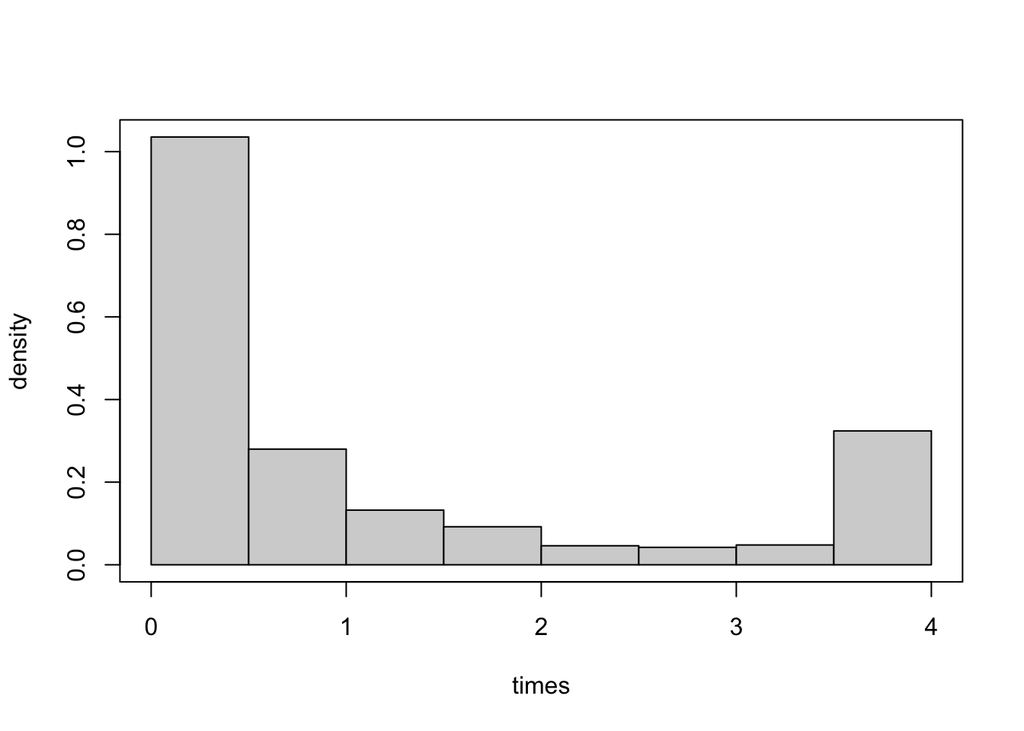

```r
# Histogram of survival times
hist(simulated_survival$times, xlab = "times", ylab ="density", probability = TRUE, main = "")
box()
```

```r
# Proportion of observed survival times
mean(simulated_survival$status)
```

```
## [1] 0.8533078
```

## MEGH-II Structure

The second proposed mixed effects hazard structure is:
$$h_2(t_{ij}\mid {\bf x}_{ij}, {\bf u}_i) = h_0\left(t_{ij} \exp\left\{\tilde{{\bf x}}_{ij}^{\top}\mathbf{\alpha} + {\bf z}_{ij}^{\top}{\bf u}_i \right\}\right)\exp\left\{{\bf x}_{ij}^{\top}\mathbf{\beta} + {\bf z}_{ij}^{\top}{\bf u}_i \right\},$$

The following R code shows how to simulate from the MEGH-II model under these assumptions for specific values of the parameters and a baseline hazard given by the [Power Generalised Weibull](https://rpubs.com/FJRubio/PGW) distribution. In order to avoid simulating design matrices, we will use the real data set `LeukSurv` from the R package `spBayesSurv`.

```r
##############################################################################################
# MEGH-II
##############################################################################################

# Required packages
library(mvtnorm)
library(MEGH)
library(spBayesSurv)

#********************************************************
# Design matrices and ID indicators based on real data
#********************************************************

data(LeukSurv)
#View(LeukSurv)
#dim(LeukSurv)

X <- as.matrix(cbind(scale(LeukSurv$age), LeukSurv$sex, scale(LeukSurv$wbc), scale(LeukSurv$tpi) ))
colnames(X) <- cbind("std age", "sex", "wbc", "tpi")
Xt <- as.matrix(cbind(scale(LeukSurv$age)))
n.ind <- dim(X)[1]  # number of individuals
n.clust <- length(unique(LeukSurv$district)) # number of clusters
q <- dim(Xt)[2]
p <- dim(X)[2]
r <- n.clust
ID <- as.vector(LeukSurv$district)


#True values of the parameters
Sigma <- 1
alpha <- 0.96
beta <- c(1.00,0.08,0.22,0.10)
theta <- c(0.2,1.50,3.0)
true_parameters <- c(sigma,theta,alpha,beta)
npar <- length(true_parameters)
cens <- 4 # censoring times


#********************************************************
# Simulation
#********************************************************
#*
simulated_survival <- simMEGH(seed=1234, des=X, des_t=Xt, ID=ID,
                              alpha=alpha, beta=beta, theta=theta, Sigma=Sigma,
                              cens=rep(cens,n.ind), restr="II", distr="PGW")

summary(simulated_survival)
```

```
##        Length Class  Mode
## times  1043   -none- numeric
## status 1043   -none- numeric
## ID     1043   -none- numeric
```

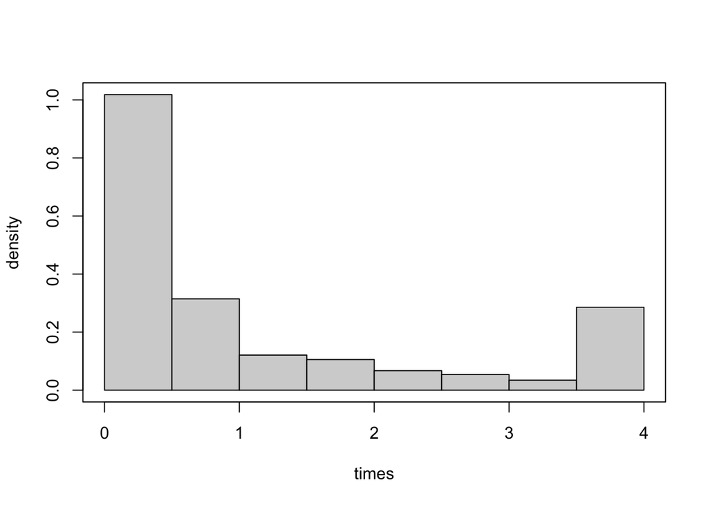

```r
# Histogram of survival times
hist(simulated_survival$times, xlab = "times", ylab ="density", probability = TRUE, main = "")
box()
```

```r
# Proportion of observed survival times
mean(simulated_survival$status)
```

```
## [1] 0.8753595
```

# References

Rubio, F. J., and R. Drikvandi. 2021. “MEGH: A Parametric Class of Mixed-Effects General Hazard Models.” *Preprint* na: na–.

Rubio, F. J., and M. F. J. Steel. 2018. “Flexible Linear Mixed Models with Improper Priors for Longitudinal and Survival Data.” *Electronic Journal of Statistics* 12: 572–98.

Therneau, T. M., and P. M. Grambsch. 2000. *Modeling Survival Data: Extending the Cox Model*. New York: Springer.